# Một số mô hình hồi quy và áp dụng đối với tập dữ liệu "Solar Radiation Prediction"

Tác giả: Đinh Minh Hải

26/01/2022

## 1. Đặt vấn đề (Introduction)

Mối liên hệ giữa lượng bức xạ mặt trời với yếu tố độ ẩm môi trường vô cùng quan trọng cho nhu cầu khai thác và chuyển hóa ánh sáng thành điện năng. Nó giúp chúng ta dự đoán nguồn cung bức xạ dựa trên độ ẩm tại chính khu vực đo đạc. Xa hơn nữa, nếu tệp dữ liệu đủ lớn, việc xây dựng một mô hình tiên đoán trữ lượng ánh sáng mặt trời quanh năm tại một khu vục cụ thể là rất khả thi, từ đó cung cấp các bằng chứng xác thực tính hợp lý khi khởi công xây dựng nông trường điện mặt trời tại địa phương. Trong tiểu luận này, dựa trên tập dữ liệu "Solar Radiation Prediction"(Andrey,2017) tôi sẽ truy tìm quy luật phụ thuộc của bức xạ mặt trời vào độ ẩm bằng một số các mô hình hồi quy với hy vọng tìm ra cách biển diễn sự phụ thuộc trên một cách chính xác nhất.

## 2. Cơ sở toán học (Preliminaries)

Các mô hình tôi sử dụng để phân tích tập dữ liệu gồm có hồi quy tuyến tính và hồi quy đa thức.

### 2.1. Ước lượng bình phương tối thiểu của tham số hồi quy tuyến tính

Phương trình hồi quy tuyến tính đơn giản (simple regression equation) là \begin{align} Y = \alpha + \beta x + e \end{align} Trong đó $x$ là giá trị của biến độc lập, $Y$ là là giá trị trả về và $e$ là sai số có trung bình là $0$

Ban đầu, chúng ta chỉ có giá trị đầu vào $x_i$ và giá trị đầu ra $Y_i$, $i = 1,\dots,n$. Để xác định mối quan hệ tuyến tính giữa $x_i$ và $Y_i$, ta cần ước lượng các tham số $\alpha$ và $\beta$. Khi đó, nếu $A$, $B$ lần lượt là ước lượng của $\alpha$ và $\beta$ thì giá trị trả về thông qua phương pháp ước lượng trên của biến $x_i$ là $A+Bx_i$. Điểm mấu chốt cần chú tâm nhất của phương pháp ước lượng $\alpha$ và $\beta$ là làm sao để giá trị ước lượng $A+Bx_i$ không sai lệch nhiều với giá trị chính xác $Y_i$. Điều này đồng nghĩa với hiệu $[Y_i - (A + Bx_i)]^2$ cần đạt giá trị nhỏ nhất. Mặt khác, vì ta đang ước lượng $A$ và $B$ sao cho phương trình hồi quy tuyến tính mô tả đúng nhất mối liên hệ trên toàn tập dữ liệu $(x_i, Y_i)$, $i = 1,\dots,n$ nên sự sai khác tương ứng với từng cặp $(x_i,Y_i)$, lúc này, cần đạt giá trị hợp lý sao cho tổng bình phương các sai lệch $\sum_{i=1}^n [Y_i - (A + Bx_i)]^2$ đạt được giá trị nhỏ nhất.

Tổng kết lại, với $A$, $B$ lần lượt là ước lượng của $\alpha$, $\beta$ và \begin{align} SSE = \sum_{i=1}^n[Y_i-(A+Bx_i)]^2 \end{align} Yêu cầu lúc này của bài toán là tìm $A$ và $B$ sao cho $SSE$ nhỏ nhất.

#### Định lý 1.1 (Định lý về ước lượng bình phương tối thiểu của tham số hồi quy)

Ước lượng bình phương tối thiểu của $\beta$ và $\alpha$ ứng với tập dữ liệu $x_i$, $Y_i$, $i = 1,\dots,n$ là \begin{align*} &B = \frac{\sum_{i=1}^n x_i Y_i - \bar{x}\sum_{i=1}^n Y_i}{\sum_{i=1}^n x_i^2 - n\bar{x}}\newline &A = \bar{Y}-B\bar{x} \end{align*} Đường thẳng $A+Bx$ được gọi là đường hồi quy (Ross, 2004).

**Chứng minh**

Với $A$, $B$ lần lượt là ước lượng của $\alpha$, $\beta$ và \begin{align*} SSE = \sum_{i=1}^n[Y_i-(A+Bx_i)]^2 \end{align*} Ta tính đạo hàm riêng theo $A$ và theo $B$ được kết quả như sau \begin{align*} \frac{dSSE}{dA}= \sum_{i=1}^n[Y_i-(A+Bx_i)] \end{align*} \begin{align*} \frac{dSSE}{dB}= \sum_{i=1}^n x_i[Y_i-(A+Bx_i)] \end{align*} Cho \begin{align*} &\frac{dSSE}{dA}=0\newline \Longrightarrow &\sum_{i=1}^n[Y_i-(A+Bx_i)] = 0\newline \Longleftrightarrow &A = \frac{1}{n}\sum_{i=1}^nY_i - \frac{B}{r}\sum_{i=1}^n x_i \end{align*} Khi này, đặt $\bar{Y} = \frac{1}{n}\sum_{i=1}^nY_i, \bar{x} = \frac{1}{n}\sum_{i=1}^n x_i $, ta được kết quả rút gọn \begin{align*} A = \bar{Y} - B\bar{x} \end{align*} Tương tự, ta cho \begin{align*} &\frac{dSSE}{dB}=0\newline \Longrightarrow &\sum_{i=1}^n x_i[Y_i-(A+Bx_i)] = 0\newline \Longleftrightarrow &\sum_{i=1}^nx_iY_i -A\sum_{i=1}^nx_i - B\sum_{i=1}^nx_i^2 = 0\newline \Longleftrightarrow &\sum_{i=1}^nx_iY_i +(B\bar{x}-\bar{Y})\sum_{i=1}^nx_i - B\sum_{i=1}^nx_i^2 = 0\newline \Longleftrightarrow &B\left(\bar{x}\sum_{i=1}^nx_i^2 - \sum_{i=1}^nx_i^2\right) = \bar{Y}\sum_{i=1}^nx_i - \sum_{i=1}^nx_iY_i \newline \Longleftrightarrow &B = \frac{\bar{Y}\sum_{i=1}^nx_i - \sum_{i=1}^nx_iY_i}{\bar{x}\sum_{i=1}^nx_i^2 - \sum_{i=1}^nx_i^2} \end{align*} Vậy $B = \frac{\bar{Y}\sum_{i=1}^nx_i - \sum_{i=1}^nx_iY_i}{\bar{x}\sum_{i=1}^nx_i^2 - \sum_{i=1}^nx_i^2}$, $A = \bar{Y} - B\bar{x}$. Ta kết thúc chứng minh.

### 2.2. Hồi quy đa thức (Polynomial Regression)

$\newcommand \tab{\text{ }}$ Phương trình hồi quy đa thức có dạng \begin{align} Y = \beta_0 + \beta_1 x^1 + \beta_2 x^2 + \cdots + \beta_r x^r + e \end{align} Trong đó, $\beta_0, \beta_1, \beta_2, \dots \beta_r$ là các hệ số hồi quy cần tìm và $e$ là sai số trung bình bằng $0$.

Ta giả sử tập dữ liệu gồm các cặp $(x_i,Y_i), i = 1, 2,\dots, n$. Ước lượng bình phương tối thiếu của các tham số $\beta_0, \beta_1, \beta_2, \dots \beta_r$ sẽ là các giá trị $B_0, B_1, B_2, \dots B_r$ thỏa mãn tổng bình phương $SSEP$ đạt giá trị nhỏ nhất với \begin{align} SSEP = \sum_{i=1}^n(Y_i- B_0- B_1x_i- B_2x_i^2-\dots - B_rx_i^r)^2 \end{align}

Để xác định các ước lượng trên, công việc đầu tiên là tính toán đạo hàm riêng lần lượt theo $B_0, B_1, B_2, \dots B_r$. Sau đó cho các đạo hàm này bằng $0$, ta sẽ thu được các phương trình bên dưới \begin{align*} \sum_{i=1}^n & Y_i = & &B_0n + B_1\sum_{i=1}^n x_i + B_2\sum_{i=1}^n x_i^2 + \cdots + & &B_r\sum_{i=1}^n x_i^r\newline \sum_{i=1}^n x_i & Y_i = & &B_0\sum_{i=1}^n x_i + B_1\sum_{i=1}^n x_i^2 + B_2\sum_{i=1}^n x_i^3 + \cdots + & &B_r\sum_{i=1}^nx_i^{r+1}\newline \sum_{i=1}^n x_i^2 & Y_i = & &B_0\sum_{i=1}^n x_i^2 + B_1\sum_{i=1}^n x_i^3 + B_2\sum_{i=1}^n x_i^4 + \cdots + & &B_r\sum_{i=1}^nx_i^{r+2}\newline \sum_{i=1}^n x_i^3 & Y_i = & &B_0\sum_{i=1}^n x_i^3 + B_1\sum_{i=1}^n x_i^4 + B_2\sum_{i=1}^n x_i^5 + \cdots + & &B_r\sum_{i=1}^nx_i^{r+3}\newline & \hspace{-0.5cm}\vdots & &\hspace{1cm}\vdots & & \hspace{0.9cm}\vdots \newline \sum_{i=1}^n x_i^r & Y_i = & &B_0\sum_{i=1}^n x_i^r + B_1\sum_{i=1}^n x_i^{r+1} + B_2\sum_{i=1}^n x_i^{r+2} + \cdots + & &B_r\sum_{i=1}^n x_i^{2r} \end{align*}

Sử dụng chúng để lập thành hệ $(r+1)$ phương trình bậc nhất với các ẩn $B_0, B_1, B_2, \dots B_r$. Dễ thấy hệ này giải được một cách dễ dàng. \begin{align*} \text{Khi đó, với các hệ số $B_0, B_1, B_2, \dots B_r$ vừa tìm được, đường cong } Y = B_0 + B_1 x^1 + B_2 x^2 + \cdots + B_r x^r \text{ chính là đường hồi quy} \end{align*}

## 3. Giải quyết vấn đề (Methods)

### 3.1 Tập dữ liệu "Solar Radiation Prediction" và những tinh chỉnh

"Solar Radiation Prediction" là tập dữ liệu khí tượng được thu thập tại trạm thời tiết HI-SEAS(đặt tại sườn núi lửa Mauna Loa) trong 4 tháng (từ tháng 9 đến tháng 12 năm 2016). Các đơn vị dữ liệu chính của tập dữ liệu bao gồm:

• Bức xạ mặt trời (watt trên mét vuông)  
• Nhiệt độ (độ F)  
• Độ ẩm (phần trăm)  
• Áp suất khí quyển (Hg)  
• Hướng gió (độ)  
• Tốc độ gió (dặm(miles) mỗi giờ)  
• Thời điểm mặt trời mọc/lặn (dựa theo giờ Hawaii)

Dựa trên mô tả của người cung cấp dữ liệu, tôi được biết 2 yếu tố "Bức xạ mặt trời" và "Độ ẩm" có liên quan đến nhau. Thật vậy, khi ánh sáng truyền qua không khí, chúng có thể bị hấp thụ, bị tán xạ hoặc phản xạ bởi các phân tử khí, hơi nước, mây,...(Solar Energy Technologies Office, n.d.). Do đó,khi nhận thức được giữa chúng có một tầng liên hệ tôi đã bắt tay vào sử dụng các mô hình hồi quy tuyến tính và hồi quy đa thức để phân tích nhóm dữ liệu bức xạ-độ ẩm với giả định chúng có một mối liên hệ tuyến tính hoặc một mối liên hệ bậc cao nào đó.

Vì hạn chế trong khả năng lập trình, tôi đã không thao tác trực tiếp trên tập dữ liệu gốc(Solar Radiation Prediction). Thay vào đó, tôi sử dụng các công cụ của phần mềm Excel sao cho tính được tổng bức xạ $SoR$ và tổng phần trăm độ ẩm $SoH$ từ lúc mặt trời mọc đến thời điểm lặn (từ 6h05 đến 18h35 mỗi ngày) sau đó chia lấy trung bình và nhận được một tập dữ liệu mới gồm: trung bình độ ẩm trong một lần đo(Mean of Humidity)- gọi nó là biến độc lập $X$ và trung bình bức xạ trong một lần đo (Mean of Solar_Radiation)- gọi là biến phụ thuộc $Y$.Cụ thể \begin{align*} X = \frac{SoH}{n}, Y =\frac{SoR}{n} \end{align*} với $n$ chính là số lần đo. Lúc này, tôi có một tập dữ liệu mới gồm 2 cột: độ ẩm, bức xạ và 116 dữ liệu mỗi cột, tương ứng với tổng số ngày trong 4 tháng (tháng 9, 10, 11, 12) bỏ đi các ngày 30/09, 30/11, 6/12, 7/12 do không có dữ liệu và các ngày 29/10 và 29/11 (do số liệu trung bình độ ẩm cao bất thường (133% vào ngày 29/10)).

### 3.2 Phân tích dữ liệu

#### 3.2.1 Mô tả dữ liệu

```python
import numpy as np
import matplotlib.pyplot as plt
import pandas as pd
```

```python
url = 'https://drive.google.com/file/d/1EG-GUiXVmT4S4G5eY71Y0zysLC0IGS00/view?usp=sharing'
file_id = url.split('/')[-2]
download_file = 'https://drive.google.com/uc?id='+ file_id
df = pd.read_csv(download_file)
df.head()
```

|  | Mean of Humidity | Mean of Solar_Radiation |
| --- | --- | --- |
| 0 | 67.401639 | 608.921803 |
| 1 | 61.168919 | 626.439932 |
| 2 | 91.832215 | 232.326309 |
| 3 | 95.585034 | 290.053197 |
| 4 | 82.154362 | 575.185503 |

```python
df.describe()
```

|  | Mean of Humidity | Mean of Solar_Radiation |
| --- | --- | --- |
| count | 116.000000 | 116.000000 |
| mean | 74.246218 | 393.832121 |
| std | 22.247755 | 144.578712 |
| min | 19.748344 | 50.483974 |
| 25% | 60.288079 | 292.778330 |
| 50% | 80.944040 | 415.255886 |
| 75% | 93.000000 | 504.108333 |
| max | 101.306667 | 626.439932 |

```python
X = df['Mean of Humidity']
X_te = np.zeros((len(X),1))
for i in range(len(X)):
  X_te[i] = X[i]
Y = df['Mean of Solar_Radiation']
print("Length of 'Mean of Humidity' unit:",len(X))
```

```
Length of 'Mean of Humidity' unit: 116
```

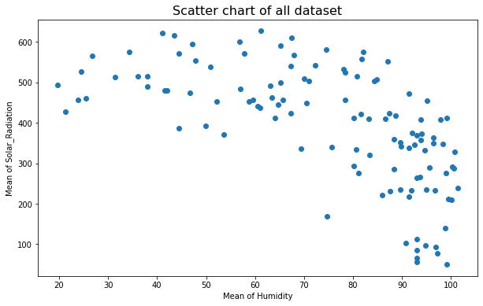

```python
fig_all_data, ax_all_data = plt.subplots(figsize=(10,6))
ax_all_data.scatter(X,Y)
plt.title("Scatter chart of all dataset", size=16)
plt.xticks()
plt.yticks()
ax_all_data.set_xlabel("Mean of Humidity")
ax_all_data.set_ylabel("Mean of Solar_Radiation")

plt.show()
```

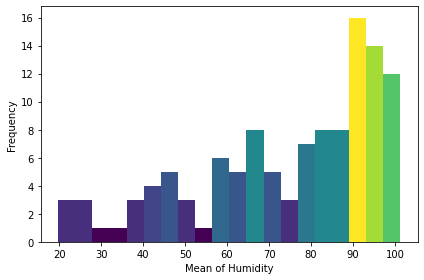

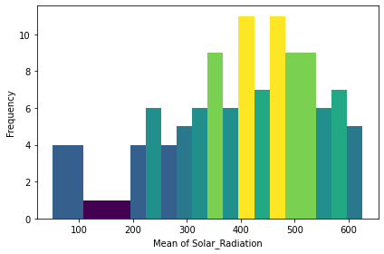

```python
# fig, axs = plt.subplots(1, 2, sharey=True, tight_layout=True)

# # We can set the number of bins with the *bins* keyword argument.
# axs[0].hist(X, bins=15)
# axs[1].hist(Y, bins=15)
from matplotlib import colors
from matplotlib.ticker import PercentFormatter
def graph_by_color(str_X_e):
    X_e = df[str_X_e]
    fig, axs = plt.subplots(1, 1, tight_layout=True)
    n_bins = 20
    # N is the count in each bin, bins is the lower-limit of the bin
    N, bins, patches = axs.hist(X_e, bins=n_bins)

    # We'll color code by height, but you could use any scalar
    fracs = N / N.max()

    # we need to normalize the data to 0..1 for the full range of the colormap
    norm = colors.Normalize(fracs.min(), fracs.max())

    # Now, we'll loop through our objects and set the color of each accordingly
    for thisfrac, thispatch in zip(fracs, patches):
        color = plt.cm.viridis(norm(thisfrac))
        thispatch.set_facecolor(color)
    axs.set_xlabel(str_X_e)
    axs.set_ylabel('Frequency')
    return None
graph_by_color('Mean of Humidity')
graph_by_color('Mean of Solar_Radiation')
# We can also normalize our inputs by the total number of counts
#axs[1].hist(X, bins=n_bins, density=True)

# Now we format the y-axis to display percentage
#axs[1].yaxis.set_major_formatter(PercentFormatter(xmax=1))
```

```python
from sklearn.model_selection import train_test_split
X_train, X_test, Y_train, Y_test = train_test_split(X_te,Y, test_size = 0.3, random_state = 10)
```

#### 3.2.2 Phương pháp phân tích dữ liệu

Để đi tìm mối liên hệ giữa trung bình độ ẩm và trung bình bức xạ mặt trời, tôi chia tập dữ liệu theo tỉ lệ $7:3$, trong đó $7$ phần được dùng để ước lượng các tham số hồi quy (tuyến tính và đa thức bậc ba), $3$ phần còn lại được dùng để xét tính hiệu quả của mô hình.

#### 3.2.3 Sử dụng mô hình hồi quy tuyến tính

```python
from sklearn.metrics import mean_squared_error
from sklearn.metrics import r2_score
from sklearn.linear_model import LinearRegression
lin_reg = LinearRegression()
```

```python
lin_reg.fit(X_train,Y_train)
```

```
LinearRegression()
```

```python
lin_reg.predict(X_test)
```

```
array([491.24892639, 305.95372547, 291.31043986, 443.21578494,
       344.86088488, 541.93651729, 298.03235775, 474.67635895,
       398.78615781, 325.07834525, 425.87373701, 407.53264719,
       326.66728297, 570.87268505, 324.1453838 , 440.77923329,
       367.10835014, 326.94410049, 300.35629212, 369.19622608,
       483.52230271, 341.72682197, 417.78935679, 415.48166891,
       304.71643566, 362.87762341, 453.51622844, 552.96546006,
       297.50759836, 423.8746537 , 310.91794577, 575.23025069,
       432.37075787, 427.19812973, 296.35812545])
```

```python
print(len(X_test))
```

```
35
```

```python
print(lin_reg.score(X_test,Y_test))
print("Coefficient: \n",lin_reg.coef_)
lin_b = lin_reg.coef_[0]
print("Mean Square error: {0:.2f}".format(mean_squared_error(Y_test,lin_reg.predict(X_test))))
print("Coefficient of determination: {0:.3f}".format(r2_score(Y_test, lin_reg.predict(X_test))))
print("Intercept: {0:.2f}".format(lin_reg.intercept_))
```

```
0.481628532535862
Coefficient:
 [-3.77326979]
Mean Square error: 11351.45
Coefficient of determination: 0.482
Intercept: 671.59
```

```python
print("Phương trình hồi quy tuyến tính chúng ta nhận được là")
from IPython.display import Math, display, Latex
display(Math(r'Y = {0:.3f}+({1:.3})x'.format(lin_reg.intercept_,lin_b)))
```

```
Phương trình hồi quy tuyến tính chúng ta nhận được là
```

$\displaystyle Y = 671.586+(-3.77)x$

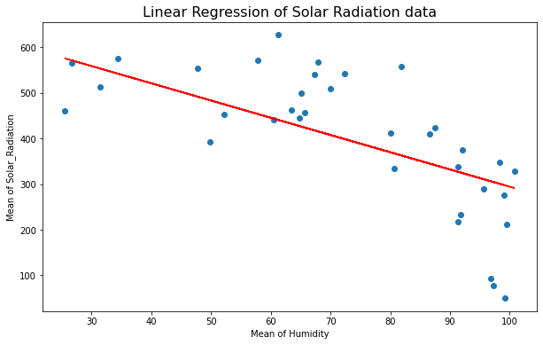

```python
fig, ax = plt.subplots(figsize=(10,6))
ax.scatter(X_test,Y_test)
ax.plot(X_test,lin_reg.predict(X_test), color="r")
plt.title("Linear Regression of Solar Radiation data", size=16)
plt.xticks()
plt.yticks()
ax.set_xlabel("Mean of Humidity")
ax.set_ylabel("Mean of Solar_Radiation")

plt.show()
```

#### 3.2.4 Sử dụng mô hình hồi quy đa thức bậc ba

```python
from sklearn.metrics import mean_squared_error
from sklearn.metrics import r2_score
from sklearn.preprocessing import PolynomialFeatures
poly = PolynomialFeatures(degree=3,include_bias=False)
```

```python
poly_features = poly.fit_transform(X_train.reshape(-1,1))
poly_features_X_test = poly.fit_transform(X_test.reshape(-1,1))
# print(poly_features_X_test)
```

```python
from sklearn.linear_model import LinearRegression
poly_reg = LinearRegression()
poly_reg.fit(poly_features,Y_train)
poly_reg.predict(poly_features_X_test)
```

```
array([517.98180757, 272.53348317, 238.9156161 , 491.39792861,
       353.26407993, 512.00478149, 254.55479611, 512.17979402,
       441.8170462 , 313.84039242, 474.74907327, 453.34537227,
       317.13401571, 491.45023566, 311.89640625, 489.27545465,
       393.29927674, 317.70559136, 259.880481  , 396.81156948,
       515.73232738, 347.25170378, 465.78510173, 463.08934716,
       269.75799512, 386.05093619, 499.56968895, 505.70097688,
       253.34640371, 472.60248717, 283.54543358, 487.21440223,
       481.40381634, 476.14565139, 250.69199706])
```

```python
print(poly_reg.score(poly_features_X_test,Y_test))
print("Coefficient: \n",poly_reg.coef_)
a = poly_reg.coef_[0]
b = poly_reg.coef_[1]
c = poly_reg.coef_[2]
print("Mean Square error: {0:.2f}".format(mean_squared_error(Y_test,poly_reg.predict(poly_features_X_test))))
print("Coefficient of determination: {0:.3f}".format(r2_score(Y_test, poly_reg.predict(poly_features_X_test))))
print("Intercept of the graph: {0:.4}".format(poly_reg.intercept_))
```

```
0.6355392516375051
Coefficient:
 [ 1.01797705e+01 -1.35228051e-01  2.69161337e-04]
Mean Square error: 7981.07
Coefficient of determination: 0.636
Intercept of the graph: 311.0
```

```python
print("Phương trình hồi quy đa thức chúng ta nhận được là")
from IPython.display import Math, display, Latex
display(Math(r'Y = {0:.3f}+{1:.3}x + {2:.3}x^{3} + ({4:.3})x^{5}'.format(poly_reg.intercept_,a,b,2,c,3)))
```

```
Phương trình hồi quy đa thức chúng ta nhận được là
```

$\displaystyle Y = 310.961+10.2x + -0.135x^2 + (0.000269)x^3$

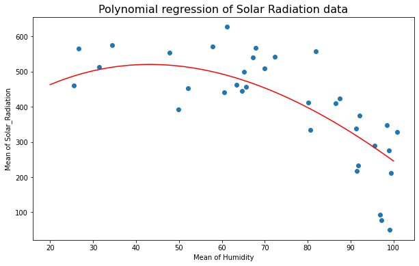

```python
plt.figure(figsize=(10, 6))
plt.title("Polynomial regression of Solar Radiation data", size=16)
plt.scatter(X_test, Y_test)
a = np.linspace(20,100, num=100).reshape(-1,1)
x = poly.fit_transform(a.reshape(-1,1))
poly_reg.predict(x)
plt.plot(a,poly_reg.predict(x) ,c="r",)
plt.xlabel('Mean of Humidity')
plt.ylabel('Mean of Solar_Radiation')
plt.show()
```

Một cách trực quan để nhận biết mô hình hồi quy có chính xác trong việc giải thích tập dữ liệu đã cho hay không là dựa vào standardized residuals(tạm dịch: số dư chuẩn, gọi tắt là $SR$). Nếu mô hình hồi quy là đúng thì các đại lượng số dư $Y_i - (A + Bx_i), i = 1, 2, \dots, n$ sau khi được chuẩn hóa (tạo thành $SR$) sẽ xấp xỉ một biến ngẫu nhiên độc lập có phân phối chuẩn. Do đó, khi minh họa trên đồ thị $SR$ nên phân bố ngẫu nhiên xung quanh đường thẳng $y=0$ và $95\%$ trong số chúng nên nằm giữa $2$ và $-2$ (vì $P\{-1.96<Z<1.96\}=0.95$)(Ross, 2004).

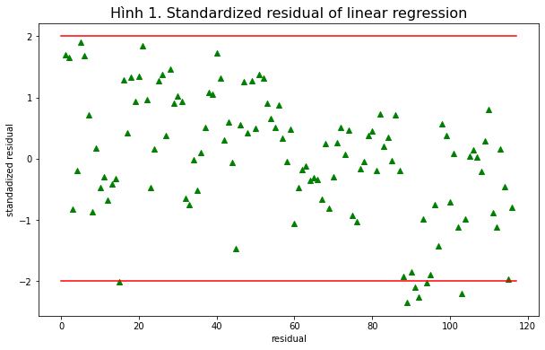

```python
# Calculate sum of squared residuals(SSR)
A = np.ones((116,)) * lin_reg.intercept_
B = lin_reg.coef_
SSR = np.sum((Y-A-B*X)**2)
MatrixSSR = (1/np.sqrt((SSR/len(X)-2)))*(Y-A-B*X)
figa, axa = plt.subplots(figsize=(10,6))
axa.scatter(np.linspace(1,116, num =116),MatrixSSR,c = "g", marker = "^")
plt.title("Hình 1. Standardized residual of linear regression", size=16)
plt.xticks()
plt.yticks()
axa.set_xlabel("residual")
axa.set_ylabel("standadized residual")
a = np.linspace(0,117, num=500).reshape(-1,1)
b = np.ones((500,))*(-2)
c = np.ones((500,))* 2
axa.plot(a,b, color="r")
axa.plot(a,c, color="r")
plt.show()
#SR cần phân bố ngẫu nhiên xung quanh y = 0, song dựa vào đồ thị dưới đây, ta thấy được thưa ở góc trên bên phải
#thưa ở góc dưới bên phải, thêm vào đó là các dữ liệu lọt ra ngoài [-2,2]
```

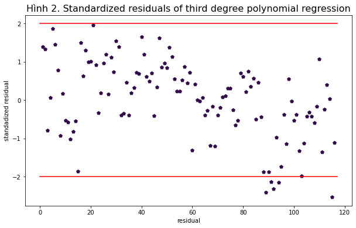

```python
# Calculate sum of squared residuals(SSR)
X_ = poly.fit_transform(np.array(X).reshape(-1,1))
# print(X_)
A = np.ones((116,)) * poly_reg.intercept_
B = poly_reg.coef_
SSR = np.sum((Y-A-B@X_.T)**2)
MatrixSSR = (1/np.sqrt((SSR/len(X)-2)))*(Y-A-B@X_.T)
figa, axa = plt.subplots(figsize=(10,6))
axa.scatter(np.linspace(1,116, num =116),MatrixSSR, c='#300948',marker='p')
plt.title("Hình 2. Standardized residuals of third degree polynomial regression", size=16)
plt.xticks()
plt.yticks()
axa.set_xlabel("residual")
axa.set_ylabel("standadized residual")
a = np.linspace(0,117, num=500).reshape(-1,1)
b = np.ones((500,))*(-2)
c = np.ones((500,))* 2
axa.plot(a,b, color="r")
axa.plot(a,c, color="r")
plt.show()
#SR cần phân bố ngẫu nhiên xung quanh y = 0, song dựa vào đồ thị dưới đây, ta thấy được thưa ở góc trên bên phải
#thưa ở góc dưới bên phải, thêm vào đó là các dữ liệu lọt ra ngoài [-2,2]
```

## 4. Kết quả (Results)

Trong chương trình trên, kết quả nhận được khi áp dụng các mô hình hồi quy tuyến tính và hồi quy đa thức để dự đoán lượng bức xạ mặt trời dựa trên độ ẩm cho trước ($30\%$ tập dữ liệu) không mấy khả quan. Giá trị $R^2$(Coefficient of detemination) lần lượt là $0.636$ cho mô hình hồi quy đa thức và $0.482$ cho mô hình hồi quy tuyến tính.

Điều này có nghĩa là chỉ $63.554\%$ dữ liệu được giải thích bởi mô hình hồi quy đa thức bậc ba, đối với hồi quy tuyến tính thì con số còn kém hơn $48.163\%$

## 5. Bàn luận (Discussion)

Mô hình hồi quy tuyến tính và hồi quy đa thức không hiệu quả trong dự đoán bức xạ ánh sáng thông qua độ ẩm môi trường, vì thế ta không thể sử dụng chúng làm cơ sở để dự báo nguồn cung năng lượng mặt trời tại địa phương, cũng như là biến chúng thành bằng chứng hợp lý hóa ý tưởng xây dựng vùng sản xuất điện mặt trời tập trung.

Mặc dù chúng ta thừa nhận các mô hình hồi quy được dùng trong bài viết này không tốt khi dự đoán tập dữ liệu nhưng với các kết quả mà nó mang lại, tôi có thể khẳng định mối tương quan tương đối mạnh giữa bức xạ và độ ẩm. Điều này củng cố lại giả định ban đầu mà tôi ngầm thừa nhận từ người cung cấp dữ liệu.

Đối với các nghiên cứu trong tương lai, tôi muốn đề xuất sử dụng thêm cột dữ liệu "Áp suất khí quyển" vào mô hình bởi mật độ các phân tử khí trong môi trường làm tác động đến sự suy giảm của bức xạ. Điều này giống như bài học từ độ ẩm: "Các phân tử nước trong không khí càng nhiều, tức độ ẩm càng cao thì mức bức xạ của mặt trời đo được tại đó càng giảm". Ngoài ra, tôi cũng rất chờ đợi dữ liệu cập nhật có thể cung cấp thêm mật độ bụi trong không gian ở các thời điểm đo đạc. Càng nhiều yếu tố ảnh hưởng hay có khả năng ảnh hưởng đến sự di chuyển của ánh sáng trong không gian. Sự có mặt của nó sẽ giúp tôi có thể bao phủ, làm hẹp đi các điểm mù về mặt dữ liệu từ đó cải thiện được mô hình hồi quy của minh.

## 6. Tài liệu tham khảo (Reference)

1. SolarEnergyTechnologiesOffice. (n.d). *Solar Radiation Basics*. Retrieved January 25,2022, from https://www.energy.gov/eere/solar/solar-radiation-basics
2. Ross, S. M. (2004). Introduction to Probability and Statistics for engineers and scientist. *Least squares estimators of the regression parameters* (pp.353-355). Elsevier.
3. Andrey. (2017). *SolarRadiationPrediction*. Retrieved January 25,2022, from https://www.kaggle.com/dronio/SolarEnergy
4. Ross, S. M. (2004). Introduction to Probability and Statistics for engineers and scientist. *Analysis of residuals: assessing the model* (pp.378-380). Elsevier.